# Maximum likelihood

Topics in Scientific and Statistical Computing

Robin Elahi

## What is likelihood?

Likelihood: (relative) measure of how well our observations fit a specific hypothesis / model

## Probability distribution functions vs likelihood functions

- parameters
- data
- summation / integration of probabilities

## Probability distribution function

**known parameter, variable data**

We **know** that the oceans cover 70% of the earth’s surface. If we were to take 10 random GPS coordinates of the earth, what’s the probability of getting 5 ocean points?

```r
p <- 0.7
```

What probability distribution should we use? Which function in R?

```r
dbinom(x = 5, size = 10, p = p)
```

```
[1] 0.1029193
```

If we repeat this calculation for every possible outcome of ocean points (out of 10), we can visualize the probability distribution, for a *known* parameter ($p$).

```r
ocean_grid <- seq(0, 10, by = 1)
ocean_p <- dbinom(x = ocean_grid, size = 10, p = p)
```

If we sum the `ocean_p` vector, what value should we get?  
Reminder: this is a probability mass function.

```r
sum(ocean_p)
```

```
[1] 1
```

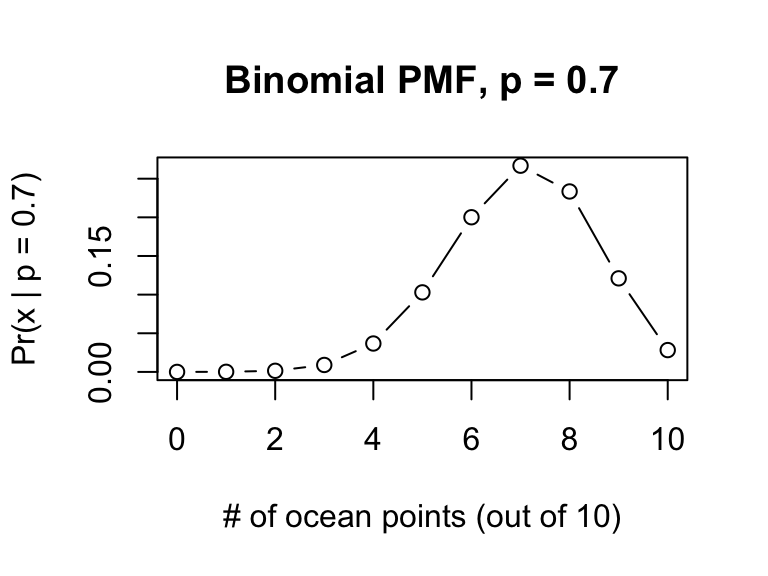

## Likelihood function

**unknown parameter, fixed data**

(the usual case)

Imagine you are martian observing Earth for the first time and you want to estimate the proportion of ocean on the planet using a bunch of random landings with your space probe.

Out of 20 trials, you made 12 ocean landings.

What is $\text{Pr}(p = 0.7 | \text{ocean} = 12, \text{trials} = 20)$?

```r
dbinom(x = 12, size = 20, prob = 0.7)
```

```
[1] 0.1143967
```

Repeat for many values of $p$:

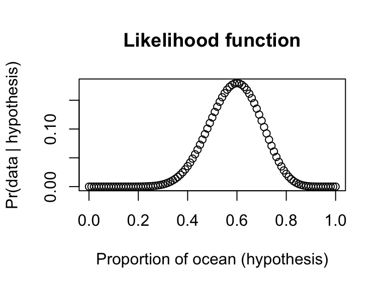

```r
p_grid <- seq(0, 1, by = 0.01)
p_lik <- dbinom(x = 12, size = 20, prob = p_grid)
plot(p_grid, p_lik, type = "b",
     xlab = "Proportion of ocean (hypothesis)",
     ylab = "Pr(data | hypothesis)",
     main = "Likelihood function")
```

Will these probabilities sum to 1?

```r
sum(p_lik)
```

```
[1] 4.761905
```

Which value of $p$ corresponds to the maximum likelihood?

```r
df <- tibble(p_grid, p_lik)
summary(df)
```

```
     p_grid         p_lik
 Min.   :0.00   Min.   :0.000e+00
 1st Qu.:0.25   1st Qu.:2.979e-05
 Median :0.50   Median :8.532e-03
 Mean   :0.50   Mean   :4.715e-02
 3rd Qu.:0.75   3rd Qu.:9.113e-02
 Max.   :1.00   Max.   :1.797e-01
```

```r
df[which.max(df$p_lik), ]
```

```
# A tibble: 1 × 2
  p_grid p_lik
   <dbl> <dbl>
1    0.6 0.180
```

## Maximum likelihood

Following slides are based on a [lab](https://github.com/mcgoodman/quant-eco-course/tree/master/Part%201%20-%20Maximum%20Likelihood/lab%201%20-%20linear%20regression) by Maurice Goodman.

## Outline

- simulate data from a linear model using a known intercept and slope
- **write a function** to fit a linear regression using **maximum-likelihood estimation**,
- compare estimated intercept and slope compare to the known values

## Linear regression

$$\begin{aligned}
Y &= \alpha + \beta X + \epsilon \\
\epsilon &\sim \text{Normal}(0, \sigma^2)
\end{aligned}$$

$$\begin{aligned}
Y &\sim \text{Normal}(\mu, \sigma^2) \\
\mu &= \alpha + \beta X
\end{aligned}$$

**Three** parameters:

- $\alpha$, the intercept
- $\beta$, the slope
- $\sigma$, the standard deviation of the residuals

## Simulate data

```r
a <- 1 ## intercept
b <- 2 ## slope
sigma <- 1 ## error standard deviation
n <- 50 ## sample size
## simulate data
set.seed(13)
sim_data <- data.frame(x = runif(n, min = -3, max = 3))
sim_data$y <- rnorm(n, mean = a + b*sim_data$x, sd = sigma)
## Look at the data structure
head(sim_data)
```

```
           x         y
1  1.2619347  3.673224
2 -1.5231762 -3.505669
3 -0.6621933 -2.351430
4 -2.4516980 -4.960354
5  2.7723873  5.816631
6 -2.9344000 -4.877011
```

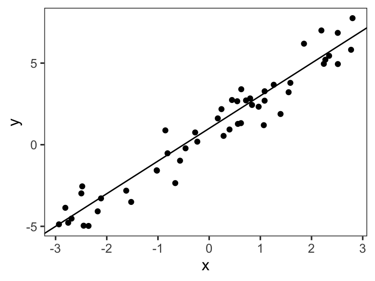

**Likelihood function**:

$$\mathcal{L}(\theta) = f_X(x|\theta) = \prod_{i = 1}^n f_X(x_i )$$

**Log-likelihood function**:

$$l(\theta) = \ln (\mathcal{L}(\theta)) = \sum_{i = 1}^n \ln [f_X(x_i)]$$

We want to maximize the log-likelihood of this function, which is equivalent to **minimizing the negative log-likelihood**.

$$\begin{aligned}
Y &= \alpha + \beta X + \epsilon \\
\epsilon &\sim \text{Normal}(0, \sigma^2)
\end{aligned}$$

becomes:

$$Y \sim \text{Normal}(\underbrace{\alpha + \beta X}_{\text{mean}}, \underbrace{\sigma^2}_{\text{variance}})$$

We can express the negative log-likelihood function in R as:

`-sum(dnorm(y, mean = ..., sd = ..., log = TRUE))`

## R function

```r
## negative log-likelihood of y-values given
## intercept, slope, and error sd
## we pass the parameters as a vector in the order a, b, sigma
lm_nll <- function(par, x, y) {
  a <- par["a"]; b <- par["b"]; sigma <- exp(par["log_sigma"])
  -sum(dnorm(y, mean = a + b*x, sd = sigma, log = TRUE))
}
```

## `optim`ize the function

```r
fit <- optim(
  par = c(a = 0, b = 0, log_sigma = 1),
  fn = lm_nll,
  x = sim_data$x,
  y = sim_data$y,
  hessian = TRUE
)
```

```r
fit
```

```
$par
         a          b  log_sigma
 0.8269008  2.0182844 -0.1061237

$value
[1] 65.64576

$counts
function gradient
     140       NA

$convergence
[1] 0

$message
NULL

$hessian
                    a             b     log_sigma
a         61.82268539   4.243509988  -0.037625973
b          4.24350999 176.478986962  -0.002715066
log_sigma -0.03762597  -0.002715066 100.020193344
```

```r
# Compare with lm
coef(lm(y ~ x, data = sim_data))
```

```
(Intercept)           x
  0.8265966   2.0182841
```

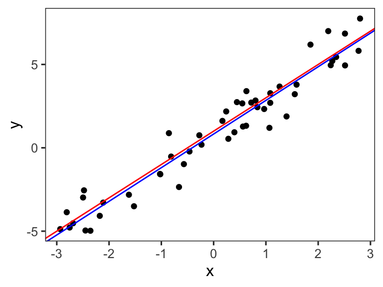

```r
sim_data %>% ggplot(aes(x, y)) + geom_point() +
  geom_abline(intercept = a, slope = b,
              color = "red") + # truth
  geom_abline(intercept = fit$par[1], slope = fit$par[2],
              color = "blue") # fit
```

## Likelihood slice

```r
a_seq <- seq(-2, 4, length.out = 100)
b_seq <- seq(-1, 5, length.out = 100)

### data frame containing all combinations of the intercept and slope
par_grid <- expand.grid("a" = a_seq, "b" = b_seq)

### loop over data frame, store negative log likelihood
for (i in 1:nrow(par_grid)) {
  par_grid$loglik[i] <- lm_nll(
    c(a = par_grid$a[i], b = par_grid$b[i], fit$par[3]),
    x = sim_data$x,
    y = sim_data$y
  )
}
```

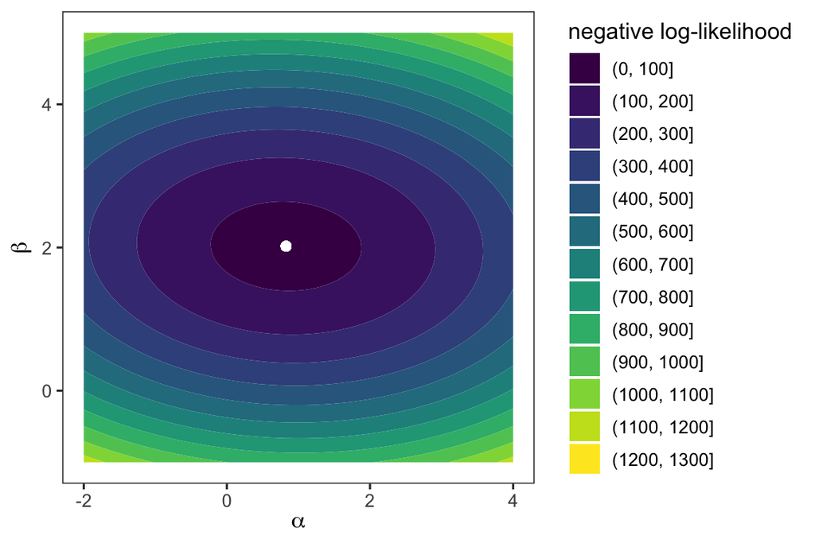

## Likelihood profile for the slope

Modify our `lm_log_lik` function so that the slope is a separate argument.

```r
slope_proflik <- function(pars, b, x, y) {
  a <- pars["a"]; sigma <- exp(pars["log_sigma"]) ## only two pars in this function
  -sum(dnorm(y, mean = a + b*x, sd = sigma, log = TRUE))
}

b_profile <- data.frame(
  b = seq(-1, 5, length.out = 100)  ## values of slope to loop over
)
```

We’ll pass this to `optim` to just find the values of the intercept and sd

```r
## loop over values of the slope, store negative log-likelihood
for (i in 1:nrow(b_profile)) {
  b_fit <- optim(
    par = c(a = 0, log_sigma = log(1)), # initial values for intercept and sd
    fn = slope_proflik,  # objective function
    b = b_profile$b[i], # fixed slope value
    x = sim_data$x,   # x values
    y = sim_data$y   # y values
  )
  b_profile$nll[i] <- b_fit$value
}
```

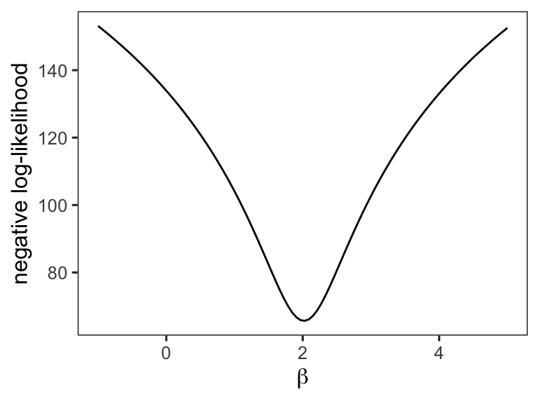

```r
## plot slope profile
b_profile %>%
  ggplot(aes(b, nll)) +
  geom_line() +
  labs(x = expression(beta), y = "negative log-likelihood")
```

## Standard errors: Fisher information

$$\begin{aligned}
\mathcal{J}(\hat{\theta}) &= - \frac{\partial^2}{\partial \theta^2} \ln [\mathcal{L}(\hat{\theta})] \\
\text{Var}(\hat{\theta}) &= 1 / \mathcal{J}(\hat{\theta})
\end{aligned}$$

```r
var_cov <- solve(fit$hessian)
var_cov
```

```
                      a             b    log_sigma
a          1.620204e-02 -3.895846e-04 6.084368e-06
b         -3.895846e-04  5.675765e-03 7.514228e-09
log_sigma  6.084368e-06  7.514228e-09 9.997983e-03
```

The variances are on the diagonal, and we can get the standard errors by taking their square root:

```r
fisher_se <- sqrt(diag(var_cov))
fisher_se
```

```
         a          b  log_sigma
0.12728722 0.07533767 0.09998992
```

Let’s compare these to the standard errors reported by `lm`:

| term | estimate | std.error | statistic | p.value |
| --- | --- | --- | --- | --- |
| (Intercept) | 0.8265966 | 0.1299250 | 6.362106 | 1e-07 |
| x | 2.0182841 | 0.0768989 | 26.245943 | 0e+00 |

## Confidence intervals: normal approximation

$$\text{CI} = (\hat{\theta} - \phi^{-1}(\gamma / 2) \times \text{SE}(\hat{\theta}), \; \hat{\theta} + \phi^{-1}(1 - \gamma / 2) \times \text{SE}(\hat{\theta}))$$

Where $\phi^{-1}$ is the inverse cumulative distribution function of the standard Normal distribution.

Equivalently:

$$\text{CI} = (\phi^{-1}_{\hat{\theta}, \text{SE}(\theta)}(\gamma / 2), \; \phi^{-1}_{\hat{\theta}, \text{SE}(\theta)} (1-\gamma/2))$$

Where $\phi^{-1}_{\hat{\theta}, \text{SE}(\theta)}$ is the inverse cumulative distribution function for a Normal distribution with mean $\hat{\theta}$ and standard deviation $\text{SE}(\theta)$.

The Normal inverse CDF is returned by the `qnorm` function. We can obtain a confidence interval for our intercept $\alpha$ and slope $\beta$:

```r
gamma <- 0.05 ## 95% confidence interval
alpha_CI <- qnorm(c(gamma/2, 1 - gamma/2), mean = fit$par[1],
                  sd = fisher_se[1])
beta_CI <- qnorm(c(gamma/2, 1 - gamma/2), mean = fit$par[2],
                 sd = fisher_se[2])
cbind(alpha_CI, beta_CI)
```

```
      alpha_CI  beta_CI
[1,] 0.5774225 1.870625
[2,] 1.0763792 2.165944
```

## Making it a function

```r
lm_fit <- function(x, y, SE = "fisher", init = c("a" = 0, "b" = 0, "log_sigma" = 0), n_boot = 1000) {

  if (!(SE %in% c("bootstrap", "fisher"))) stop("SE options are bootstrap or fisher")
  if (length(x) != length(y)) stop("x and y lengths differ")

  ## Maximum-likelihood estimate
  MLE <- optim(
    par = init, # initial values
    fn = lm_nll,  # our negative log-likelihood function
    x = x,   # x values
    y = y,   # y values
    hessian = (SE == "fisher") # only return Hessian if Fisher information used
  )

  ## Standard error using either fisher information or bootstrapping
  if (SE == "fisher") {
    var_cov <- solve(MLE$hessian)
    fit_se <- sqrt(diag(var_cov))
  } else {
    n_obs <- length(x) ## number of observations

    ## initialize an empty matrix to store parameter estimates for each sample
    par_samples <- matrix(nrow = n_boot, ncol = 3)

    ## recalculate MLE for each sample
    for (i in 1:n_boot) {
      samp <- sample(1:n_obs, size = n_obs, replace = TRUE) # sampled observations
      new_x <- x[samp] # subset x to sampled observations
      new_y <- y[samp] # subset y to sampled observations

      sample_fit <- optim(
        par = init, # initial values
        fn = lm_nll, # log likelihood function
        x = new_x, # sampled x-values
        y = new_y # sampled y-values
      )

    par_samples[i,] <- sample_fit$par # store sample parameters
  }
  fit_se <- apply(par_samples, MARGIN = 2, FUN = sd) # calculate column SDs
 }

 ## nicely format output
 data.frame(
   coef = c("intercept", "slope"),
   estimate = MLE$par[1:2],
   SE = fit_se[1:2]
 )

}
```

## Lab exercise 1

```r
a <- 1 ## intercept
b <- 2 ## slope
sigma <- 1 ## error standard deviation
n <- 50 ## sample size

## simulate data
sim_data <- tibble(
  x = runif(n, min = -3, max = 3), ## x values
  y = rnorm(n, mean = a + b*x, sd = sigma) ## regression equation
)

## plot data
sim_data %>% ggplot(aes(x, y)) + geom_point() + geom_smooth(method = "lm")
```

```r
## run regression
lm_fit(sim_data$x, sim_data$y, SE = "fisher")
```

```
       coef  estimate         SE
a intercept 0.9358099 0.13386046
b     slope 2.0485483 0.07308945
```

[figure not shown]